[figure not shown]

# WELCOME!

Welcome to "*Employee Churn Analysis Project*". This is the second project of Capstone Project Series, which you will be able to build your own classification models for a variety of business settings.

Also you will learn what is Employee Churn?, How it is different from customer churn, Exploratory data analysis and visualization of employee churn dataset using *matplotlib* and *seaborn*, model building and evaluation using python *scikit-learn* package.

You will be able to implement classification techniques in Python. Using Scikit-Learn allowing you to successfully make predictions with the Random Forest, Gradient Boosting Descent, KNN algorithms.

At the end of the project, you will have the opportunity to deploy your model using *Streamlit*.

Before diving into the project, please take a look at the determines and project structure.

- NOTE: This tutorial assumes that you already know the basics of coding in Python and are familiar with model deployement as well as the theory behind K-Means, Gradient Boosting Descent, KNN, Random Forest, and Confusion Matrices.

# #Determines

In this project you have HR data of a company. A study is requested from you to predict which employee will churn by using this data.

The HR dataset has 14,999 samples. In the given dataset, you have two types of employee one who stayed and another who left the company.

You can describe 10 attributes in detail as:

- *satisfaction_level:* It is employee satisfaction point, which ranges from 0-1.
- *last_evaluation:* It is evaluated performance by the employer, which also ranges from 0-1.
- *number_projects:* How many of projects assigned to an employee?
- *average_monthly_hours:* How many hours in averega an employee worked in a month?
- **time_spent_company:** time_spent_company means employee experience. The number of years spent by an employee in the company.
- *work_accident:* Whether an employee has had a work accident or not.
- *promotion_last_5years:* Whether an employee has had a promotion in the last 5 years or not.
- *Departments:* Employee's working department/division.
- *Salary:* Salary level of the employee such as low, medium and high.
- *left:* Whether the employee has left the company or not.

First of all, to observe the structure of the data, outliers, missing values and features that affect the target variable, you must use exploratory data analysis and data visualization techniques.

Then, you must perform data pre-processing operations such as *Scaling* and *Label Encoding* to increase the accuracy score of Gradient Descent Based or Distance-Based algorithms. you are asked to perform *Cluster Analysis* based on the information you obtain during exploratory data analysis and data visualization processes.

The purpose of clustering analysis is to cluster data with similar characteristics. You are asked to use the *K-means* algorithm to make cluster analysis. However, you must provide the K-means algorithm with information about the number of clusters it will make predictions. Also, the data you apply to the K-means algorithm must be scaled. In order to find the optimal number of clusters, you are asked to use the *Elbow method*. Briefly, try to predict the set to which individuals are related by using K-means and evaluate the estimation results.

Once the data is ready to be applied to the model, you must *split the data into train and test*. Then build a model to predict whether employees will churn or not. Train your models with your train set, test the success of your model with your test set.

Try to make your predictions by using the algorithms *Gradient Boosting Classifier*, *K Neighbors Classifier*, *Random Forest Classifier*. You can use the related modules of the *scikit-learn* library. You can use scikit-learn *Confusion Metrics* module for accuracy calculation. You can use the *Yellowbrick* module for model selection and visualization.

In the final step, you will deploy your model using Streamlit tool.

# #Tasks

#### 1. Exploratory Data Analysis

- Importing Modules
- Loading Dataset
- Data Insigts

#### 2. Data Visualization

- Employees Left
- Determine Number of Projects
- Determine Time Spent in Company
- Subplots of Features

#### 3. Data Pre-Processing

- Scaling
- Label Encoding

#### 4. Cluster Analysis

- Find the optimal number of clusters (k) using the elbow method for for K-means.
- Determine the clusters by using K-Means then Evaluate predicted results.

#### 5. Model Building

- Split Data as Train and Test set
- Built Gradient Boosting Classifier, Evaluate Model Performance and Predict Test Data
- Built K Neighbors Classifier and Evaluate Model Performance and Predict Test Data
- Built Random Forest Classifier and Evaluate Model Performance and Predict Test Data

#### 6. Model Deployement

- Save and Export the Model as .pkl
- Save and Export Variables as .pkl

## 1. Exploratory Data Analysis

Exploratory Data Analysis is an initial process of analysis, in which you can summarize characteristics of data such as pattern, trends, outliers, and hypothesis testing using descriptive statistics and visualization.

### Importing Modules

```python
import pandas as pd
import numpy as np
import seaborn as sns
import matplotlib.pyplot as plt
```

```python
from sklearn.preprocessing import scale, StandardScaler
from sklearn.model_selection import train_test_split, GridSearchCV, cross_val_score
from sklearn.metrics import confusion_matrix, accuracy_score, mean_squared_error, r2_score, roc_auc_score, roc_curve, classification_report, f1_score
from sklearn.linear_model import LogisticRegression
from sklearn.neighbors import KNeighborsClassifier
from sklearn.tree import DecisionTreeClassifier
from sklearn.ensemble import RandomForestClassifier
from sklearn.ensemble import GradientBoostingClassifier
import warnings
warnings.filterwarnings("ignore")
```

### Loading Dataset

Let's first load the required HR dataset using pandas's "read_csv" function.

```python
df = pd.read_csv("HR_Dataset.csv")
df
```

|  | satisfaction_level | last_evaluation | number_project | average_montly_hours | time_spend_company | Work_accident | left | promotion_last_5years | Departments | salary |
| --- | --- | --- | --- | --- | --- | --- | --- | --- | --- | --- |
| 0 | 0.38 | 0.53 | 2 | 157 | 3 | 0 | 1 | 0 | sales | low |
| 1 | 0.80 | 0.86 | 5 | 262 | 6 | 0 | 1 | 0 | sales | medium |
| 2 | 0.11 | 0.88 | 7 | 272 | 4 | 0 | 1 | 0 | sales | medium |
| 3 | 0.72 | 0.87 | 5 | 223 | 5 | 0 | 1 | 0 | sales | low |
| 4 | 0.37 | 0.52 | 2 | 159 | 3 | 0 | 1 | 0 | sales | low |
| ... | ... | ... | ... | ... | ... | ... | ... | ... | ... | ... |
| 14994 | 0.40 | 0.57 | 2 | 151 | 3 | 0 | 1 | 0 | support | low |
| 14995 | 0.37 | 0.48 | 2 | 160 | 3 | 0 | 1 | 0 | support | low |
| 14996 | 0.37 | 0.53 | 2 | 143 | 3 | 0 | 1 | 0 | support | low |
| 14997 | 0.11 | 0.96 | 6 | 280 | 4 | 0 | 1 | 0 | support | low |
| 14998 | 0.37 | 0.52 | 2 | 158 | 3 | 0 | 1 | 0 | support | low |

14999 rows × 10 columns

```python
df.shape
```

```
(14999, 10)
```

```python
df.info()
```

```
<class 'pandas.core.frame.DataFrame'>
RangeIndex: 14999 entries, 0 to 14998
Data columns (total 10 columns):
 #   Column                 Non-Null Count  Dtype
---  ------                 --------------  -----
 0   satisfaction_level     14999 non-null  float64
 1   last_evaluation        14999 non-null  float64
 2   number_project         14999 non-null  int64
 3   average_montly_hours   14999 non-null  int64
 4   time_spend_company     14999 non-null  int64
 5   Work_accident          14999 non-null  int64
 6   left                   14999 non-null  int64
 7   promotion_last_5years  14999 non-null  int64
 8   Departments            14999 non-null  object
 9   salary                 14999 non-null  object
dtypes: float64(2), int64(6), object(2)
memory usage: 1.1+ MB
```

```python
df.describe().T
```

|  | count | mean | std | min | 25% | 50% | 75% | max |
| --- | --- | --- | --- | --- | --- | --- | --- | --- |
| satisfaction_level | 14999.0 | 0.612834 | 0.248631 | 0.09 | 0.44 | 0.64 | 0.82 | 1.0 |
| last_evaluation | 14999.0 | 0.716102 | 0.171169 | 0.36 | 0.56 | 0.72 | 0.87 | 1.0 |
| number_project | 14999.0 | 3.803054 | 1.232592 | 2.00 | 3.00 | 4.00 | 5.00 | 7.0 |
| average_montly_hours | 14999.0 | 201.050337 | 49.943099 | 96.00 | 156.00 | 200.00 | 245.00 | 310.0 |
| time_spend_company | 14999.0 | 3.498233 | 1.460136 | 2.00 | 3.00 | 3.00 | 4.00 | 10.0 |
| Work_accident | 14999.0 | 0.144610 | 0.351719 | 0.00 | 0.00 | 0.00 | 0.00 | 1.0 |
| left | 14999.0 | 0.238083 | 0.425924 | 0.00 | 0.00 | 0.00 | 0.00 | 1.0 |
| promotion_last_5years | 14999.0 | 0.021268 | 0.144281 | 0.00 | 0.00 | 0.00 | 0.00 | 1.0 |

### Data Insights

In the given dataset, you have two types of employee one who stayed and another who left the company. So, you can divide data into two groups and compare their characteristics. Here, you can find the average of both the groups using groupby() and mean() function.

```python
df.duplicated().value_counts()  # probable
```

```
False    11991
True      3008
dtype: int64
```

```python
df_stay = df.groupby("left", as_index=False).mean()
df_stay
```

|  | left | satisfaction_level | last_evaluation | number_project | average_montly_hours | time_spend_company | Work_accident | promotion_last_5years |
| --- | --- | --- | --- | --- | --- | --- | --- | --- |
| 0 | 0 | 0.666810 | 0.715473 | 3.786664 | 199.060203 | 3.380032 | 0.175009 | 0.026251 |
| 1 | 1 | 0.440098 | 0.718113 | 3.855503 | 207.419210 | 3.876505 | 0.047326 | 0.005321 |

## 2. Data Visualization

You can search for answers to the following questions using data visualization methods. Based on these responses, you can develop comments about the factors that cause churn.

- How does the promotion status affect employee churn?
- How does years of experience affect employee churn?
- How does workload affect employee churn?
- How does the salary level affect employee churn?

### Employees Left

Let's check how many employees were left? Here, you can plot a bar graph using Matplotlib. The bar graph is suitable for showing discrete variable counts.

```python
df[df.left == 1].left.sum()
```

```
3571
```

```python
left_df = df.groupby("left", as_index=False).left.count()
left_df
```

|  | left |
| --- | --- |
| 0 | 11428 |
| 1 | 3571 |

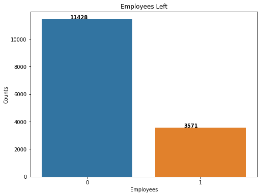

```python
plt.figure(figsize=(8,6))
ax = sns.barplot(x=left_df.index, y=left_df.left)
plt.title('Employees Left')
plt.xlabel('Employees')
plt.ylabel("Counts")
# calculate the counts and annotate the sns barplot
for rect in ax.patches:
    ax.text(rect.get_x() - 0.15 + rect.get_width() / 2,rect.get_height() + 20,"%.f"% rect.get_height(), weight='bold' )
plt.show()
plt.show()
```

### Number of Projects

Similarly, you can also plot a bar graph to count the number of employees deployed on how many projects?

```python
df.columns
```

```
Index(['satisfaction_level', 'last_evaluation', 'number_project',
       'average_montly_hours', 'time_spend_company', 'Work_accident', 'left',
       'promotion_last_5years', 'Departments ', 'salary'],
      dtype='object')
```

```python
pro_df = df.groupby(["number_project", "left"]).number_project.count().to_frame(name="count").reset_index()
pro_df
```

|  | number_project | left | count |
| --- | --- | --- | --- |
| 0 | 2 | 0 | 821 |
| 1 | 2 | 1 | 1567 |
| 2 | 3 | 0 | 3983 |
| 3 | 3 | 1 | 72 |
| 4 | 4 | 0 | 3956 |
| 5 | 4 | 1 | 409 |
| 6 | 5 | 0 | 2149 |
| 7 | 5 | 1 | 612 |
| 8 | 6 | 0 | 519 |
| 9 | 6 | 1 | 655 |
| 10 | 7 | 1 | 256 |

```
posx and posy should be finite values
posx and posy should be finite values
```

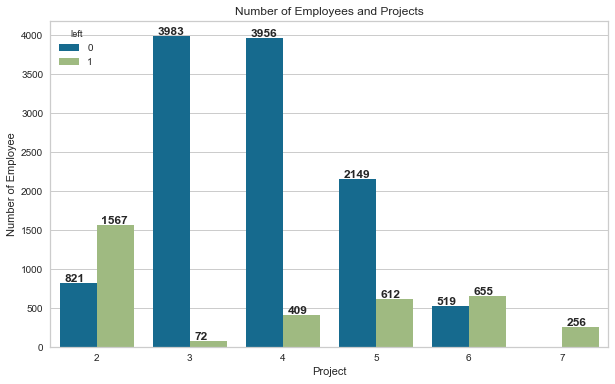

```python
plt.figure(figsize=(10,6))
ax = sns.barplot(x=pro_df.number_project, y=pro_df["count"], hue=pro_df.left)
plt.title('Number of Employees and Projects')
plt.xlabel('Project')
plt.ylabel("Number of Employee")
# calculate the counts and annotate the sns barplot
for rect in ax.patches:
    ax.text(rect.get_x() - 0.15 + rect.get_width() / 2,rect.get_height() + 20,"%.f"% rect.get_height(), weight='bold')
plt.show()
```

```python
project_df = df.groupby(["number_project","left"]).number_project.count().to_frame(name="employee")
project_df
```

| number_project | left | employee |
| --- | --- | --- |
| 2 | 0 | 821 |
|  | 1 | 1567 |
| 3 | 0 | 3983 |
|  | 1 | 72 |
| 4 | 0 | 3956 |
|  | 1 | 409 |
| 5 | 0 | 2149 |
|  | 1 | 612 |
| 6 | 0 | 519 |
|  | 1 | 655 |
| 7 | 1 | 256 |

```python
project_df.reset_index(inplace=True)
project_df
```

|  | number_project | left | employee |
| --- | --- | --- | --- |
| 0 | 2 | 0 | 821 |
| 1 | 2 | 1 | 1567 |
| 2 | 3 | 0 | 3983 |
| 3 | 3 | 1 | 72 |
| 4 | 4 | 0 | 3956 |
| 5 | 4 | 1 | 409 |
| 6 | 5 | 0 | 2149 |
| 7 | 5 | 1 | 612 |
| 8 | 6 | 0 | 519 |
| 9 | 6 | 1 | 655 |
| 10 | 7 | 1 | 256 |

```
posx and posy should be finite values
posx and posy should be finite values
```

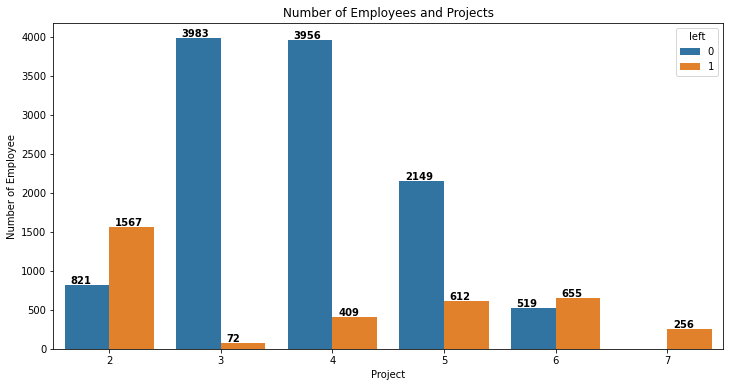

```python
plt.figure(figsize=(12,6))
ax = sns.barplot(x=project_df.number_project, y=project_df.employee, hue=project_df.left)
plt.title('Number of Employees and Projects')
plt.xlabel('Project')
plt.ylabel("Number of Employee")
# calculate the counts and annotate the sns barplot
for rect in ax.patches:
    ax.text(rect.get_x() - 0.15 + rect.get_width() / 2,rect.get_height() + 20,"%.f"% rect.get_height(), weight='bold')
plt.show()
```

### Time Spent in Company

Similarly, you can also plot a bar graph to count the number of employees have based on how much experience?

```python
time_df = df.time_spend_company.value_counts(dropna=False, ascending=False).to_frame(name="time_spent")
time_df
```

|  | time_spent |
| --- | --- |
| 3 | 6443 |
| 2 | 3244 |
| 4 | 2557 |
| 5 | 1473 |
| 6 | 718 |
| 10 | 214 |
| 7 | 188 |
| 8 | 162 |

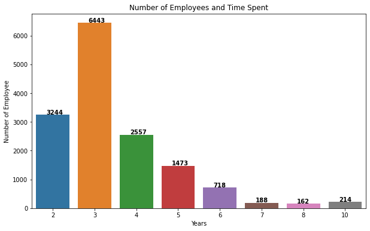

```python
plt.figure(figsize=(10,6))
ax = sns.barplot(x=time_df.index, y=time_df.time_spent)
plt.title('Number of Employees and Time Spent')
plt.xlabel('Years')
plt.ylabel("Number of Employee")
# calculate the counts and annotate the sns barplot
for rect in ax.patches:
    ax.text(rect.get_x() - 0.15 + rect.get_width() / 2,rect.get_height() + 20,"%.f"% rect.get_height(), weight='bold' )
plt.show()
plt.show()
```

```python
t_df = df.groupby(["time_spend_company","left"]).time_spend_company.count().to_frame(name="employee")
t_df.reset_index(inplace=True)
```

```python
t_df
```

|  | time_spend_company | left | employee |
| --- | --- | --- | --- |
| 0 | 2 | 0 | 3191 |
| 1 | 2 | 1 | 53 |
| 2 | 3 | 0 | 4857 |
| 3 | 3 | 1 | 1586 |
| 4 | 4 | 0 | 1667 |
| 5 | 4 | 1 | 890 |
| 6 | 5 | 0 | 640 |
| 7 | 5 | 1 | 833 |
| 8 | 6 | 0 | 509 |
| 9 | 6 | 1 | 209 |
| 10 | 7 | 0 | 188 |
| 11 | 8 | 0 | 162 |
| 12 | 10 | 0 | 214 |

```
posx and posy should be finite values
posx and posy should be finite values
posx and posy should be finite values
posx and posy should be finite values
posx and posy should be finite values
posx and posy should be finite values
```

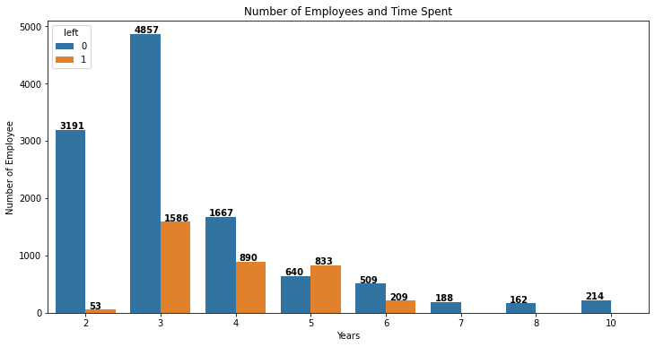

```python
plt.figure(figsize=(12,6))
ax = sns.barplot(x=t_df.time_spend_company, y=t_df.employee, hue=t_df.left)
plt.title('Number of Employees and Time Spent')
plt.xlabel('Years')
plt.ylabel("Number of Employee")
# calculate the counts and annotate the sns barplot
for rect in ax.patches:
    ax.text(rect.get_x() - 0.15 + rect.get_width() / 2,rect.get_height() + 20,"%.f"% rect.get_height(), weight='bold')
plt.show()
```

### Subplots of Features

You can use the methods of the matplotlib.

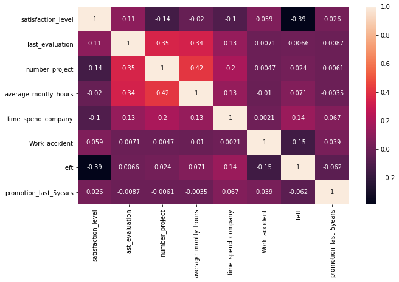

```python
plt.figure(figsize=(10,6))
sns.heatmap(df.corr(),annot=True)
plt.show()
```

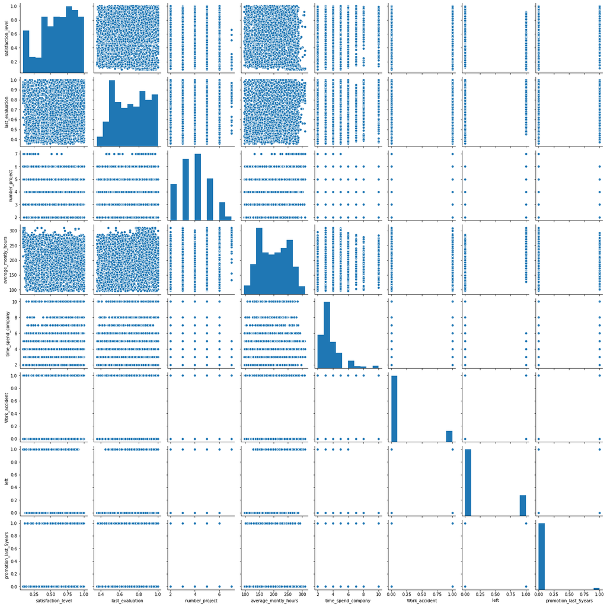

```python
plt.figure(figsize=(10,6))
sns.pairplot(df)
plt.show()
```

## 3. Data Pre-Processing

#### Scaling

Some machine learning algorithms are sensitive to feature scaling while others are virtually invariant to it. Machine learning algorithms like linear regression, logistic regression, neural network, etc. that use gradient descent as an optimization technique require data to be scaled. Also distance algorithms like KNN, K-means, and SVM are most affected by the range of features. This is because behind the scenes they are using distances between data points to determine their similarity.

Scaling Types:

- Normalization: Normalization is a scaling technique in which values are shifted and rescaled so that they end up ranging between 0 and 1. It is also known as Min-Max scaling.
- Standardization: Standardization is another scaling technique where the values are centered around the mean with a unit standard deviation. This means that the mean of the attribute becomes zero and the resultant distribution has a unit standard deviation.

```python
df.info()
```

```
<class 'pandas.core.frame.DataFrame'>
RangeIndex: 14999 entries, 0 to 14998
Data columns (total 10 columns):
 #   Column                 Non-Null Count  Dtype
---  ------                 --------------  -----
 0   satisfaction_level     14999 non-null  float64
 1   last_evaluation        14999 non-null  float64
 2   number_project         14999 non-null  int64
 3   average_montly_hours   14999 non-null  int64
 4   time_spend_company     14999 non-null  int64
 5   Work_accident          14999 non-null  int64
 6   left                   14999 non-null  int64
 7   promotion_last_5years  14999 non-null  int64
 8   Departments            14999 non-null  object
 9   salary                 14999 non-null  object
dtypes: float64(2), int64(6), object(2)
memory usage: 1.1+ MB
```

```python
df.head()
```

|  | satisfaction_level | last_evaluation | number_project | average_montly_hours | time_spend_company | Work_accident | left | promotion_last_5years | Departments | salary |
| --- | --- | --- | --- | --- | --- | --- | --- | --- | --- | --- |
| 0 | 0.38 | 0.53 | 2 | 157 | 3 | 0 | 1 | 0 | sales | low |
| 1 | 0.80 | 0.86 | 5 | 262 | 6 | 0 | 1 | 0 | sales | medium |
| 2 | 0.11 | 0.88 | 7 | 272 | 4 | 0 | 1 | 0 | sales | medium |
| 3 | 0.72 | 0.87 | 5 | 223 | 5 | 0 | 1 | 0 | sales | low |
| 4 | 0.37 | 0.52 | 2 | 159 | 3 | 0 | 1 | 0 | sales | low |

```python
df.rename(columns={"Departments ": "Departments"}, inplace=True)
```

```python
df["Departments"].value_counts(dropna=False)
```

```
sales          4140
technical      2720
support        2229
IT             1227
product_mng     902
marketing       858
RandD           787
accounting      767
hr              739
management      630
Name: Departments, dtype: int64
```

```python
from sklearn.preprocessing import StandardScaler
```

```python
X = df.drop(columns=["Departments", "salary", "left"])
X_cat = df[["Departments", "salary"]]
```

```python
scaler = StandardScaler()  # standardization
```

```python
scaled_X = scaler.fit_transform(X)
scaled_X[0]
```

```
array([-0.93649469, -1.08727529, -1.46286291, -0.88203988, -0.34123516,
       -0.41116529, -0.14741182])
```

```python
scaled_df = pd.DataFrame(scaled_X, columns=X.columns)
scaled_df.head()
```

|  | satisfaction_level | last_evaluation | number_project | average_montly_hours | time_spend_company | Work_accident | promotion_last_5years |
| --- | --- | --- | --- | --- | --- | --- | --- |
| 0 | -0.936495 | -1.087275 | -1.462863 | -0.882040 | -0.341235 | -0.411165 | -0.147412 |
| 1 | 0.752814 | 0.840707 | 0.971113 | 1.220423 | 1.713436 | -0.411165 | -0.147412 |
| 2 | -2.022479 | 0.957554 | 2.593763 | 1.420657 | 0.343655 | -0.411165 | -0.147412 |
| 3 | 0.431041 | 0.899131 | 0.971113 | 0.439508 | 1.028546 | -0.411165 | -0.147412 |
| 4 | -0.976716 | -1.145699 | -1.462863 | -0.841993 | -0.341235 | -0.411165 | -0.147412 |

#### Label Encoding

Lots of machine learning algorithms require numerical input data, so you need to represent categorical columns in a numerical column. In order to encode this data, you could map each value to a number. e.g. Salary column's value can be represented as low:0, medium:1, and high:2. This process is known as label encoding, and sklearn conveniently will do this for you using LabelEncoder.

```python
from sklearn.preprocessing import LabelEncoder
```

```python
le = LabelEncoder()
X_cat["Departments"] = le.fit_transform(X_cat["Departments"])
X_cat
```

|  | Departments | salary |
| --- | --- | --- |
| 0 | 7 | low |
| 1 | 7 | medium |
| 2 | 7 | medium |
| 3 | 7 | low |
| 4 | 7 | low |
| ... | ... | ... |
| 14994 | 8 | low |
| 14995 | 8 | low |
| 14996 | 8 | low |
| 14997 | 8 | low |
| 14998 | 8 | low |

14999 rows × 2 columns

```python
df.Departments.value_counts()
```

```
sales          4140
technical      2720
support        2229
IT             1227
product_mng     902
marketing       858
RandD           787
accounting      767
hr              739
management      630
Name: Departments, dtype: int64
```

```python
X_cat.Departments.value_counts()
```

```
7    4140
9    2720
8    2229
0    1227
6     902
5     858
1     787
2     767
3     739
4     630
Name: Departments, dtype: int64
```

```python
# X_cat["salary"] = X_cat["salary"].astype("category")
```

```python
# X_cat.info()
```

```python
# X_cat["salary"].cat.codes.sample(20)
```

```python
X_cat["salary"] = X_cat["salary"].apply(lambda x: 0 if x == "low" else ( 1 if x == "medium" else 2))
```

```python
X_cat.sample(8)
```

|  | Departments | salary |
| --- | --- | --- |
| 12332 | 7 | 0 |
| 13222 | 9 | 1 |
| 11538 | 7 | 1 |
| 6923 | 8 | 2 |
| 11395 | 4 | 2 |
| 12744 | 9 | 0 |
| 38 | 9 | 0 |
| 7550 | 0 | 0 |

```python
df.iloc[6923]
```

```
satisfaction_level          0.67
last_evaluation             0.73
number_project                 4
average_montly_hours         251
time_spend_company             3
Work_accident                  0
left                           0
promotion_last_5years          0
Departments              support
salary                      high
Name: 6923, dtype: object
```

```python
df.iloc[7550]
```

```
satisfaction_level       0.22
last_evaluation          0.62
number_project              6
average_montly_hours      142
time_spend_company          3
Work_accident               0
left                        0
promotion_last_5years       0
Departments                IT
salary                    low
Name: 7550, dtype: object
```

```python
scaled_df.head(2)
```

|  | satisfaction_level | last_evaluation | number_project | average_montly_hours | time_spend_company | Work_accident | promotion_last_5years |
| --- | --- | --- | --- | --- | --- | --- | --- |
| 0 | -0.936495 | -1.087275 | -1.462863 | -0.882040 | -0.341235 | -0.411165 | -0.147412 |
| 1 | 0.752814 | 0.840707 | 0.971113 | 1.220423 | 1.713436 | -0.411165 | -0.147412 |

```python
X_cat.head(2)
```

|  | Departments | salary |
| --- | --- | --- |
| 0 | 7 | 0 |
| 1 | 7 | 1 |

#### concat

```python
X_new = pd.concat([scaled_df, X_cat], axis=1)
```

```python
X_new
```

|  | satisfaction_level | last_evaluation | number_project | average_montly_hours | time_spend_company | Work_accident | promotion_last_5years | Departments | salary |
| --- | --- | --- | --- | --- | --- | --- | --- | --- | --- |
| 0 | -0.936495 | -1.087275 | -1.462863 | -0.882040 | -0.341235 | -0.411165 | -0.147412 | 7 | 0 |
| 1 | 0.752814 | 0.840707 | 0.971113 | 1.220423 | 1.713436 | -0.411165 | -0.147412 | 7 | 1 |
| 2 | -2.022479 | 0.957554 | 2.593763 | 1.420657 | 0.343655 | -0.411165 | -0.147412 | 7 | 1 |
| 3 | 0.431041 | 0.899131 | 0.971113 | 0.439508 | 1.028546 | -0.411165 | -0.147412 | 7 | 0 |
| 4 | -0.976716 | -1.145699 | -1.462863 | -0.841993 | -0.341235 | -0.411165 | -0.147412 | 7 | 0 |
| ... | ... | ... | ... | ... | ... | ... | ... | ... | ... |
| 14994 | -0.856051 | -0.853580 | -1.462863 | -1.002181 | -0.341235 | -0.411165 | -0.147412 | 8 | 0 |
| 14995 | -0.976716 | -1.379394 | -1.462863 | -0.821970 | -0.341235 | -0.411165 | -0.147412 | 8 | 0 |
| 14996 | -0.976716 | -1.087275 | -1.462863 | -1.162368 | -0.341235 | -0.411165 | -0.147412 | 8 | 0 |
| 14997 | -2.022479 | 1.424944 | 1.782438 | 1.580845 | 0.343655 | -0.411165 | -0.147412 | 8 | 0 |
| 14998 | -0.976716 | -1.145699 | -1.462863 | -0.862016 | -0.341235 | -0.411165 | -0.147412 | 8 | 0 |

14999 rows × 9 columns

```python
X_new[["Departments", "salary"]] = scaler.fit_transform(X_new[["Departments", "salary"]])
```

```python
X_new  # scaled data frame without label column "left"
```

|  | satisfaction_level | last_evaluation | number_project | average_montly_hours | time_spend_company | Work_accident | promotion_last_5years | Departments | salary |
| --- | --- | --- | --- | --- | --- | --- | --- | --- | --- |
| 0 | -0.936495 | -1.087275 | -1.462863 | -0.882040 | -0.341235 | -0.411165 | -0.147412 | 0.393725 | -0.933368 |
| 1 | 0.752814 | 0.840707 | 0.971113 | 1.220423 | 1.713436 | -0.411165 | -0.147412 | 0.393725 | 0.636092 |
| 2 | -2.022479 | 0.957554 | 2.593763 | 1.420657 | 0.343655 | -0.411165 | -0.147412 | 0.393725 | 0.636092 |
| 3 | 0.431041 | 0.899131 | 0.971113 | 0.439508 | 1.028546 | -0.411165 | -0.147412 | 0.393725 | -0.933368 |
| 4 | -0.976716 | -1.145699 | -1.462863 | -0.841993 | -0.341235 | -0.411165 | -0.147412 | 0.393725 | -0.933368 |
| ... | ... | ... | ... | ... | ... | ... | ... | ... | ... |
| 14994 | -0.856051 | -0.853580 | -1.462863 | -1.002181 | -0.341235 | -0.411165 | -0.147412 | 0.742316 | -0.933368 |
| 14995 | -0.976716 | -1.379394 | -1.462863 | -0.821970 | -0.341235 | -0.411165 | -0.147412 | 0.742316 | -0.933368 |
| 14996 | -0.976716 | -1.087275 | -1.462863 | -1.162368 | -0.341235 | -0.411165 | -0.147412 | 0.742316 | -0.933368 |
| 14997 | -2.022479 | 1.424944 | 1.782438 | 1.580845 | 0.343655 | -0.411165 | -0.147412 | 0.742316 | -0.933368 |
| 14998 | -0.976716 | -1.145699 | -1.462863 | -0.862016 | -0.341235 | -0.411165 | -0.147412 | 0.742316 | -0.933368 |

14999 rows × 9 columns

## 4. Cluster Analysis

- Cluster analysis or clustering is the task of grouping a set of objects in such a way that objects in the same group (called a cluster) are more similar (in some sense) to each other than to those in other groups (clusters). It is a main task of exploratory data mining, and a common technique for statistical data analysis, used in many fields, including pattern recognition, image analysis, information retrieval, bioinformatics, data compression, computer graphics and machine learning.

  [Cluster Analysis](https://en.wikipedia.org/wiki/Cluster_analysis)

  [Cluster Analysis2](https://realpython.com/k-means-clustering-python/)

#### The Elbow Method

- "Elbow Method" can be used to find the optimum number of clusters in cluster analysis. The elbow method is used to determine the optimal number of clusters in k-means clustering. The elbow method plots the value of the cost function produced by different values of k. If k increases, average distortion will decrease, each cluster will have fewer constituent instances, and the instances will be closer to their respective centroids. However, the improvements in average distortion will decline as k increases. The value of k at which improvement in distortion declines the most is called the elbow, at which we should stop dividing the data into further clusters.

  The Elbow Method

  [The Elbow Method2](https://medium.com/@mudgalvivek2911/machine-learning-clustering-elbow-method-4e8c2b404a5d)

  [KMeans](https://towardsdatascience.com/understanding-k-means-clustering-in-machine-learning-6a6e67336aa1)

```python
scaled_df = pd.concat([X_new, df[["left"]]], axis=1)
scaled_df.sample(10)
```

|  | satisfaction_level | last_evaluation | number_project | average_montly_hours | time_spend_company | Work_accident | promotion_last_5years | Departments | salary | left |
| --- | --- | --- | --- | --- | --- | --- | --- | --- | --- | --- |
| 10577 | -1.821371 | 0.081199 | 0.159788 | -0.081102 | -1.026126 | -0.411165 | -0.147412 | 1.090907 | -0.933368 | 0 |
| 9375 | -0.011397 | -1.262546 | -0.651538 | 0.599696 | -0.341235 | -0.411165 | -0.147412 | -2.046413 | 2.205553 | 0 |
| 3741 | 0.189711 | -1.846783 | -1.462863 | -0.922087 | 1.028546 | 2.432112 | -0.147412 | 0.742316 | 0.636092 | 0 |
| 12594 | -2.062701 | 0.314894 | 1.782438 | 1.080259 | 0.343655 | -0.411165 | -0.147412 | -0.652048 | -0.933368 | 1 |
| 4313 | 0.310376 | -0.736733 | 0.159788 | 1.300517 | 0.343655 | -0.411165 | -0.147412 | 1.090907 | 0.636092 | 0 |
| 14545 | -2.062701 | 0.548588 | 1.782438 | 1.781079 | 0.343655 | -0.411165 | -0.147412 | -1.349230 | 0.636092 | 1 |
| 10207 | -0.333170 | -0.912004 | 0.971113 | 0.699813 | 0.343655 | 2.432112 | -0.147412 | 0.742316 | 2.205553 | 0 |
| 14756 | 0.672371 | 1.658639 | 0.971113 | 0.699813 | 1.028546 | -0.411165 | -0.147412 | 0.393725 | 0.636092 | 1 |
| 6634 | 1.195252 | 0.373317 | 0.159788 | -0.962134 | -0.341235 | -0.411165 | -0.147412 | -1.697822 | 0.636092 | 0 |
| 5380 | 0.350598 | -1.204123 | -0.651538 | 1.100282 | -0.341235 | -0.411165 | -0.147412 | 1.090907 | -0.933368 | 0 |

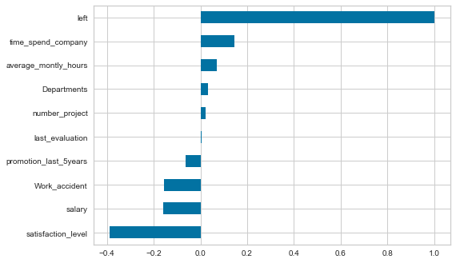

```python
scaled_df.corr()["left"].sort_values().plot.barh()
```

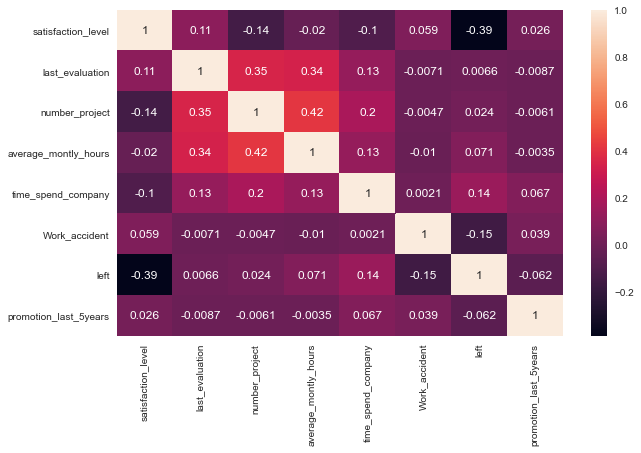

```python
plt.figure(figsize=(10,6))
sns.heatmap(df.corr(),annot=True)
plt.show()
```

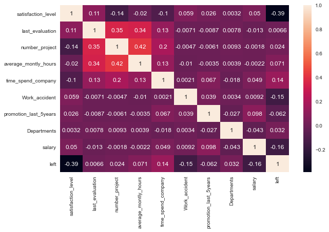

```python
plt.figure(figsize=(10,6))
sns.heatmap(scaled_df.corr(),annot=True)
plt.show()
```

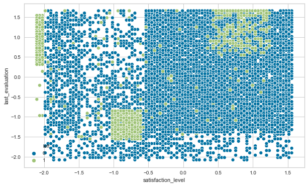

```python
plt.figure(figsize=(10, 6))
sns.scatterplot(scaled_df['satisfaction_level'], scaled_df['last_evaluation'], hue=scaled_df["left"])
plt.show()
```

#### K-Means

##### Hopkins

```python
from pyclustertend import hopkins
hopkins(X_new, X_new.shape[0])
```

```
0.11298864635765125
```

```python
left_X_new = scaled_df[scaled_df.left == 1].drop("left", axis=1)
```

```python
left_X_new.head()
```

|  | satisfaction_level | last_evaluation | number_project | average_montly_hours | time_spend_company | Work_accident | promotion_last_5years | Departments | salary |
| --- | --- | --- | --- | --- | --- | --- | --- | --- | --- |
| 0 | -0.936495 | -1.087275 | -1.462863 | -0.882040 | -0.341235 | -0.411165 | -0.147412 | 0.393725 | -0.933368 |
| 1 | 0.752814 | 0.840707 | 0.971113 | 1.220423 | 1.713436 | -0.411165 | -0.147412 | 0.393725 | 0.636092 |
| 2 | -2.022479 | 0.957554 | 2.593763 | 1.420657 | 0.343655 | -0.411165 | -0.147412 | 0.393725 | 0.636092 |
| 3 | 0.431041 | 0.899131 | 0.971113 | 0.439508 | 1.028546 | -0.411165 | -0.147412 | 0.393725 | -0.933368 |
| 4 | -0.976716 | -1.145699 | -1.462863 | -0.841993 | -0.341235 | -0.411165 | -0.147412 | 0.393725 | -0.933368 |

```python
left_X_new.shape
```

```
(3571, 9)
```

```python
hopkins(left_X_new, left_X_new.shape[0])
```

```
0.03158821793311898
```

Assess the clusterability of a dataset. A score between 0 and 1, a score around 0.5 express no clusterability and a score tending to 0 express a high cluster tendency.

##### Elbow

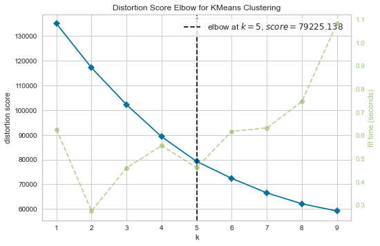

```python
from sklearn.cluster import KMeans
from yellowbrick.cluster import KElbowVisualizer

kmeans = KMeans()
visu = KElbowVisualizer(kmeans, k = (1,10))
visu.fit(X_new)
visu.poof()
```

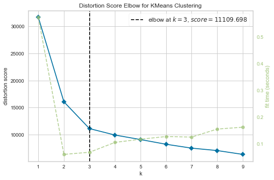

```python
from sklearn.cluster import KMeans
from yellowbrick.cluster import KElbowVisualizer

kmeans = KMeans()
visu = KElbowVisualizer(kmeans, k = (1,10))
visu.fit(left_X_new)
visu.poof()
```

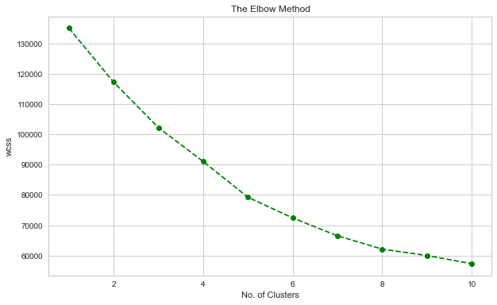

```python
wcss =[]
for n in range(1,11):
    kmeans=KMeans(n_clusters=n,random_state=0)
    kmeans.fit(X_new)
    wcss.append(kmeans.inertia_)
plt.figure(figsize=(10,6))
plt.plot(range(1, 11), wcss, color='green', marker='o', linestyle='dashed')
plt.title('The Elbow Method')
plt.xlabel('No. of Clusters')
plt.ylabel('wcss')
plt.show()
```

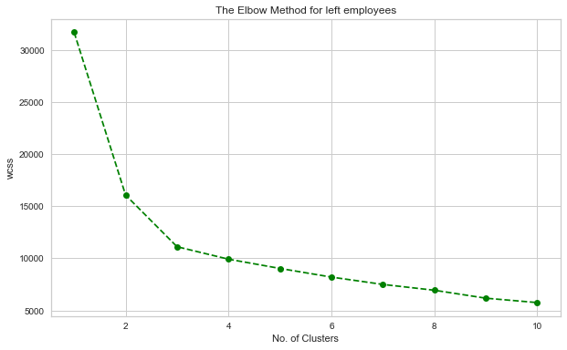

```python
wcss =[]
for n in range(1,11):
    kmeans=KMeans(n_clusters=n,random_state=0)
    kmeans.fit(left_X_new)
    wcss.append(kmeans.inertia_)
plt.figure(figsize=(10,6))
plt.plot(range(1, 11), wcss, color='green', marker='o', linestyle='dashed')
plt.title('The Elbow Method for left employees')
plt.xlabel('No. of Clusters')
plt.ylabel('wcss')
plt.show()
```

##### Silhouette

```python
from sklearn.metrics import silhouette_score
```

The silhouette coefficient for a data point measures how similar it is to its assigned cluster from -1 (dissimilar) to 1 (similar).

```python
kmeans = KMeans(n_clusters = 3)
y_means = kmeans.fit_predict(X_new)
silhouette_score(X_new, y_means)
```

```
0.17721610047225078
```

```python
kmeans = KMeans(n_clusters = 3)
y_means = kmeans.fit_predict(left_X_new)
silhouette_score(left_X_new, y_means)
```

```
0.48559267966694375
```

```python
kmeans = KMeans(n_clusters = 5)
y_means = kmeans.fit_predict(X_new)
silhouette_score(X_new, y_means)
```

```
0.1778677402343226
```

```python
kmeans = KMeans(n_clusters = 5)
y_means = kmeans.fit_predict(left_X_new)
silhouette_score(left_X_new, y_means)
```

```
0.3607828535015429
```

```python
kmeans_model = KMeans(n_clusters = 3).fit(X_new)
```

```python
kmeans_model_left = KMeans(n_clusters = 3).fit(left_X_new)
```

```python
y_means = kmeans_model.predict(X_new)
X_new["cluster_Kmeans"] = y_means
```

```python
y_means_left = kmeans_model_left.predict(left_X_new)
left_X_new["cluster_Kmeans"] = y_means_left
```

```python
kmeans_model.cluster_centers_
```

```
array([[ 1.73698319e-01, -5.89082191e-02, -4.11361711e-02,
        -2.40443015e-02,  4.57445845e-01,  2.66229900e-01,
         6.78371644e+00, -1.85438856e-01,  6.65611975e-01],
       [ 1.07354530e-01, -4.96955181e-01, -4.81246483e-01,
        -5.04270039e-01, -3.64358604e-01,  2.48419166e-02,
        -1.47411822e-01,  2.38069583e-04,  1.02350851e-02],
       [-1.55388950e-01,  6.81027390e-01,  6.58682783e-01,
         6.89215917e-01,  4.73595830e-01, -4.75701745e-02,
        -1.47411822e-01,  9.20249761e-03, -4.81609963e-02]])
```

```python
labels = kmeans_model.labels_
```

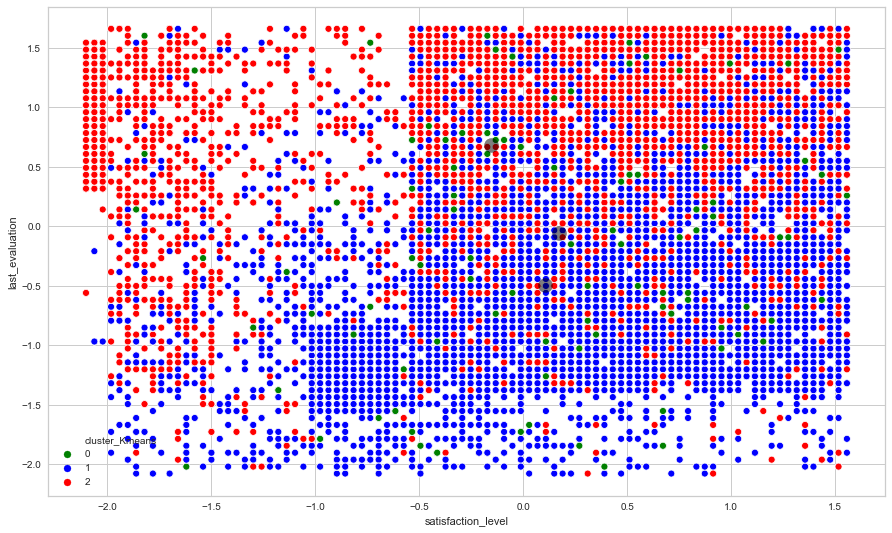

```python
plt.figure(figsize=(15,9))
sns.scatterplot(x='satisfaction_level', y="last_evaluation", hue='cluster_Kmeans', data=X_new, palette=['green','blue','red'], legend='full')
plt.scatter(kmeans_model.cluster_centers_[:, 0], kmeans_model.cluster_centers_[:, 1], s=200, c='black',alpha=0.5, label = 'Centroids')
```

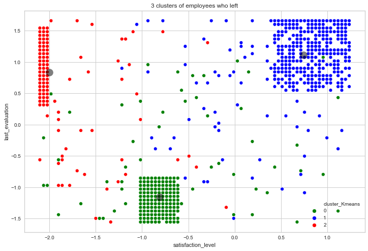

```python
plt.figure(figsize=(12,8))
sns.scatterplot(x='satisfaction_level', y="last_evaluation", hue='cluster_Kmeans', data=left_X_new, palette=['green','blue','red'], legend='full')
plt.title("3 clusters of employees who left")
plt.scatter(kmeans_model_left.cluster_centers_[:, 0], kmeans_model_left.cluster_centers_[:, 1], s=200, c='black',alpha=0.5, label = 'Centroids')
```

##### left employees

```python
scaled_df["cluster_Kmeans"] = y_means  #
```

```python
left_scaled_df = scaled_df[scaled_df.left == 1]
left_scaled_df.head()
```

|  | satisfaction_level | last_evaluation | number_project | average_montly_hours | time_spend_company | Work_accident | promotion_last_5years | Departments | salary | left | cluster_Kmeans |
| --- | --- | --- | --- | --- | --- | --- | --- | --- | --- | --- | --- |
| 0 | -0.936495 | -1.087275 | -1.462863 | -0.882040 | -0.341235 | -0.411165 | -0.147412 | 0.393725 | -0.933368 | 1 | 1 |
| 1 | 0.752814 | 0.840707 | 0.971113 | 1.220423 | 1.713436 | -0.411165 | -0.147412 | 0.393725 | 0.636092 | 1 | 2 |
| 2 | -2.022479 | 0.957554 | 2.593763 | 1.420657 | 0.343655 | -0.411165 | -0.147412 | 0.393725 | 0.636092 | 1 | 2 |
| 3 | 0.431041 | 0.899131 | 0.971113 | 0.439508 | 1.028546 | -0.411165 | -0.147412 | 0.393725 | -0.933368 | 1 | 2 |
| 4 | -0.976716 | -1.145699 | -1.462863 | -0.841993 | -0.341235 | -0.411165 | -0.147412 | 0.393725 | -0.933368 | 1 | 1 |

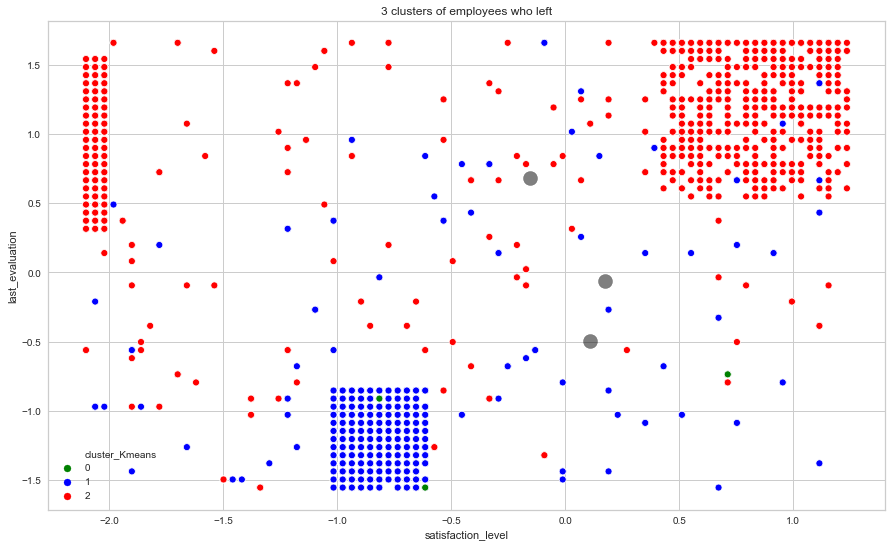

```python
plt.figure(figsize=(15,9))
sns.scatterplot(x='satisfaction_level', y="last_evaluation", hue='cluster_Kmeans', data=left_scaled_df, palette=['green','blue','red'], legend='full')
plt.scatter(kmeans_model.cluster_centers_[:, 0], kmeans_model.cluster_centers_[:, 1], s=200, c='black',alpha=0.5, label = 'Centroids')
plt.title("3 clusters of employees who left")
```

## 5. Model Building

```python
X_new.head()
```

[output not shown]

```python
scaled_df.head()
```

|  | satisfaction_level | last_evaluation | number_project | average_montly_hours | time_spend_company | Work_accident | promotion_last_5years | Departments | salary | left | cluster_Kmeans |
| --- | --- | --- | --- | --- | --- | --- | --- | --- | --- | --- | --- |
| 0 | -0.936495 | -1.087275 | -1.462863 | -0.882040 | -0.341235 | -0.411165 | -0.147412 | 0.393725 | -0.933368 | 1 | 1 |
| 1 | 0.752814 | 0.840707 | 0.971113 | 1.220423 | 1.713436 | -0.411165 | -0.147412 | 0.393725 | 0.636092 | 1 | 2 |
| 2 | -2.022479 | 0.957554 | 2.593763 | 1.420657 | 0.343655 | -0.411165 | -0.147412 | 0.393725 | 0.636092 | 1 | 2 |
| 3 | 0.431041 | 0.899131 | 0.971113 | 0.439508 | 1.028546 | -0.411165 | -0.147412 | 0.393725 | -0.933368 | 1 | 2 |
| 4 | -0.976716 | -1.145699 | -1.462863 | -0.841993 | -0.341235 | -0.411165 | -0.147412 | 0.393725 | -0.933368 | 1 | 1 |

```python
X = scaled_df.drop(["left", "cluster_Kmeans"], axis=1)
```

```python
y = scaled_df["left"]
```

```python
y.shape
```

```
(14999,)
```

### Split Data as Train and Test Set

Here, Dataset is broken into two parts in ratio of 70:30. It means 70% data will used for model training and 30% for model testing.

*Stratified splits are desirable in some cases, like when you’re classifying an imbalanced dataset, a dataset with a significant difference in the number of samples that belong to distinct classes. If you want to (approximately) keep the proportion of y values through the training and test sets, then pass stratify=y. This will enable stratified splitting*

```python
from sklearn.model_selection import train_test_split
X_train, X_test, y_train, y_test = train_test_split(X, y, test_size = 0.3, stratify=y, random_state = 0)
```

```python
y_train.shape
```

```
(10499,)
```

```python
X_train, X_val, y_train, y_val = train_test_split(X_train, y_train, test_size = 0.20, stratify=y_train, random_state = 0)
```

```python
X_train.shape
```

```
(8399, 9)
```

```python
y_train.shape
```

```
(8399,)
```

```python
X_test.shape
```

```
(4500, 9)
```

```python
y_test.shape
```

```
(4500,)
```

```python
X_val.shape
```

```
(2100, 9)
```

```python
y_val.shape
```

```
(2100,)
```

### #Gradient Boosting Classifier

*Gradient boosting classifiers are a group of machine learning algorithms that combine many weak learning models together to create a strong predictive model. Decision trees are usually used when doing gradient boosting.*

#### Model Building

```python
from sklearn.ensemble import GradientBoostingClassifier

gb_model = GradientBoostingClassifier().fit(X_train, y_train)
y_pred = gb_model.predict(X_test)
```

#### Evaluating Model Performance

- Confusion Matrix : You can use scikit-learn metrics module for accuracy calculation. A Confusion matrix is an N x N matrix used for evaluating the performance of a classification model, where N is the number of target classes. The matrix compares the actual target values with those predicted by the machine learning model. This gives us a holistic view of how well our classification model is performing and what kinds of errors it is making.

  [Confusion Matrix](https://www.analyticsvidhya.com/blog/2020/04/confusion-matrix-machine-learning/)

```python
print(confusion_matrix(y_test, y_pred))
print(classification_report(y_test, y_pred))
```

```
[[3393   36]
 [  74  997]]
              precision    recall  f1-score   support

           0       0.98      0.99      0.98      3429
           1       0.97      0.93      0.95      1071

    accuracy                           0.98      4500
   macro avg       0.97      0.96      0.97      4500
weighted avg       0.98      0.98      0.98      4500
```

```python
cnf_matrix_1 = confusion_matrix(y_test, y_pred)
cnf_matrix_1
```

```
array([[3393,   36],
       [  74,  997]], dtype=int64)
```

```python
cnf_matrix_2 = confusion_matrix( y_pred, y_test)
cnf_matrix_2
```

```
array([[3393,   74],
       [  36,  997]], dtype=int64)
```

[figure not shown]

```python
sns.heatmap(pd.DataFrame(cnf_matrix_1), annot=True, cmap="YlGnBu", fmt='g')

plt.ylabel('Predicted Label')
plt.xlabel('Actual Label')
```

- Yellowbrick: Yellowbrick is a suite of visualization and diagnostic tools that will enable quicker model selection. It’s a Python package that combines scikit-learn and matplotlib. Some of the more popular visualization tools include model selection, feature visualization, classification and regression visualization

  [Yellowbrick](https://www.analyticsvidhya.com/blog/2018/05/yellowbrick-a-set-of-visualization-tools-to-accelerate-your-model-selection-process/)

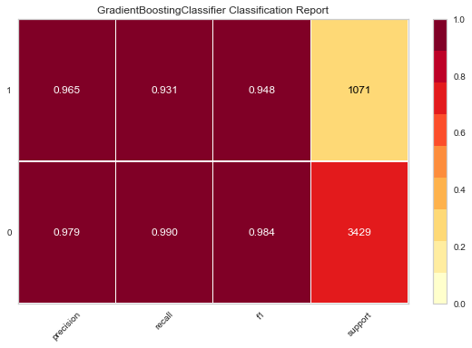

```python
from yellowbrick.classifier import ClassificationReport

visualizer = ClassificationReport(gb_model, support=True)
visualizer.fit(X_train, y_train)        # Fit the visualizer and the model
visualizer.score(X_test, y_test)        # Evaluate the model on the test data
visualizer.show()
```

#### Prediction

```python
# saving model
import pickle
pickle.dump(gb_model, open("gb_model", 'wb'))  # our model is saved.
```

```python
# recall model
saved_model = pickle.load(open("gb_model", "rb"))  # our model is called
```

```python
# prediction
prediction = saved_model.predict(X_val)  # X_val is a scaled validation data
```

```python
df_pred = y_val.to_frame()
df_pred.head()
```

|  | left |
| --- | --- |
| 8206 | 0 |
| 11665 | 0 |
| 7155 | 0 |
| 7977 | 0 |
| 1399 | 1 |

```python
df_pred["pred"] = prediction
```

```python
df_pred.sample(15)
```

|  | left | pred |
| --- | --- | --- |
| 9539 | 0 | 0 |
| 1959 | 1 | 1 |
| 12571 | 1 | 1 |
| 7540 | 0 | 0 |
| 2856 | 0 | 0 |
| 14893 | 1 | 1 |
| 12600 | 1 | 1 |
| 12870 | 0 | 0 |
| 604 | 1 | 1 |
| 8132 | 0 | 0 |
| 13055 | 0 | 0 |
| 2800 | 0 | 0 |
| 10344 | 0 | 0 |
| 2347 | 0 | 0 |
| 6706 | 0 | 0 |

### #KNeighbors Classifier

#### Model Building

```python
knn_model = KNeighborsClassifier().fit(X_train, y_train)
y_pred = knn_model.predict(X_test)
```

#### Evaluating Model Performance

```python
print(confusion_matrix(y_test, y_pred))
print(classification_report(y_test, y_pred))
```

```
[[3335   94]
 [  94  977]]
              precision    recall  f1-score   support

           0       0.97      0.97      0.97      3429
           1       0.91      0.91      0.91      1071

    accuracy                           0.96      4500
   macro avg       0.94      0.94      0.94      4500
weighted avg       0.96      0.96      0.96      4500
```

```python
cnf_matrix = confusion_matrix(y_test, y_pred)
cnf_matrix
```

```
array([[3335,   94],
       [  94,  977]], dtype=int64)
```

[figure not shown]

```python
sns.heatmap(pd.DataFrame(cnf_matrix), annot=True, cmap="YlGnBu", fmt='g')

plt.ylabel('Predicted Label')
plt.xlabel('Actual Label')
```

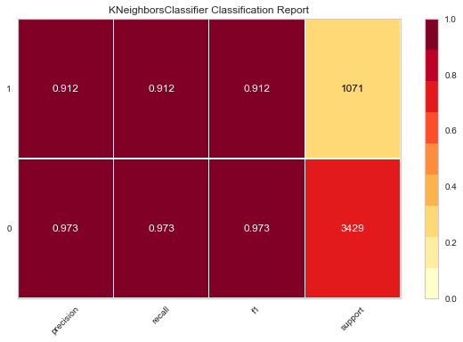

```python
from yellowbrick.classifier import ClassificationReport

visualizer = ClassificationReport(knn_model, support=True)
visualizer.fit(X_train, y_train)        # Fit the visualizer and the model
visualizer.score(X_test, y_test)        # Evaluate the model on the test data
visualizer.show()
```

#### Model Tuning (GridsearchCV)

```python
knn = KNeighborsClassifier()
```

```python
np.arange(1, 50)
```

```
array([ 1,  2,  3,  4,  5,  6,  7,  8,  9, 10, 11, 12, 13, 14, 15, 16, 17,
       18, 19, 20, 21, 22, 23, 24, 25, 26, 27, 28, 29, 30, 31, 32, 33, 34,
       35, 36, 37, 38, 39, 40, 41, 42, 43, 44, 45, 46, 47, 48, 49])
```

```python
knn_params = {"n_neighbors": np.arange(1,50)}
```

```python
knn_cv_model = GridSearchCV(knn, knn_params, cv=10).fit(X_train, y_train)
```

```python
knn_cv_model.best_params_
```

```
{'n_neighbors': 2}
```

```python
knn_tuned_model = KNeighborsClassifier(n_neighbors = 2).fit(X_train, y_train)
```

```python
y_pred = knn_tuned_model.predict(X_test)
print(confusion_matrix(y_test, y_pred))
print(classification_report(y_test, y_pred))
```

```
[[3358   71]
 [  97  974]]
              precision    recall  f1-score   support

           0       0.97      0.98      0.98      3429
           1       0.93      0.91      0.92      1071

    accuracy                           0.96      4500
   macro avg       0.95      0.94      0.95      4500
weighted avg       0.96      0.96      0.96      4500
```

```python
cnf_matrix = confusion_matrix(y_test, y_pred)
cnf_matrix  # much better prediction on the values of zero
```

```
array([[3358,   71],
       [  97,  974]], dtype=int64)
```

[figure not shown]

```python
sns.heatmap(pd.DataFrame(cnf_matrix), annot=True, cmap="YlGnBu", fmt='g')

plt.ylabel('Predicted Label')
plt.xlabel('Actual Label')
```

#### Prediction

```python
# saving model
import pickle
pickle.dump(knn_tuned_model, open("knn_model", 'wb'))  # our model is saved.
```

```python
# recall model
saved_model = pickle.load(open("knn_model", "rb"))  # our model is called
```

```python
# prediction
prediction = saved_model.predict(X_val)  # X_val is a scaled validation data
```

```python
df_pred = y_val.to_frame()
df_pred.head()
```

|  | left |
| --- | --- |
| 8206 | 0 |
| 11665 | 0 |
| 7155 | 0 |
| 7977 | 0 |
| 1399 | 1 |

```python
df_pred["pred"] = prediction
```

```python
df_pred.sample(15)
```

|  | left | pred |
| --- | --- | --- |
| 12315 | 1 | 1 |
| 11908 | 0 | 0 |
| 7547 | 0 | 0 |
| 613 | 1 | 1 |
| 3242 | 0 | 0 |
| 14495 | 1 | 1 |
| 13371 | 0 | 0 |
| 3624 | 0 | 0 |
| 10495 | 0 | 0 |
| 12609 | 1 | 1 |
| 10143 | 0 | 0 |
| 9925 | 0 | 0 |
| 9005 | 0 | 0 |
| 6069 | 0 | 0 |
| 5253 | 0 | 0 |

### #Random Forest Classifier

#### Model Building

```python
rf_model = RandomForestClassifier().fit(X_train, y_train)
y_pred = rf_model.predict(X_test)
```

#### Evaluating Model Performance

```python
print(confusion_matrix(y_test, y_pred))
print(classification_report(y_test, y_pred))
```

```
[[3424    5]
 [  37 1034]]
              precision    recall  f1-score   support

           0       0.99      1.00      0.99      3429
           1       1.00      0.97      0.98      1071

    accuracy                           0.99      4500
   macro avg       0.99      0.98      0.99      4500
weighted avg       0.99      0.99      0.99      4500
```

[figure not shown]

```python
cnf_matrix = confusion_matrix(y_test, y_pred)
sns.heatmap(pd.DataFrame(cnf_matrix), annot=True, cmap="YlGnBu", fmt='g')

plt.ylabel('Predicted Label')
plt.xlabel('Actual Label')
```

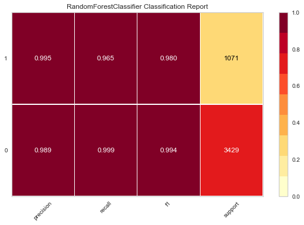

```python
from yellowbrick.classifier import ClassificationReport

visualizer = ClassificationReport(rf_model, support=True)
visualizer.fit(X_train, y_train)        # Fit the visualizer and the model
visualizer.score(X_test, y_test)        # Evaluate the model on the test data
visualizer.show()
```

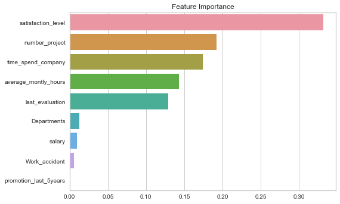

```python
feature_imp = pd.Series(rf_model.feature_importances_,
                        index=X_train.columns).sort_values(ascending=False)
sns.barplot(x=feature_imp, y=feature_imp.index)
plt.title("Feature Importance")
plt.show()
```

#### Prediction

```python
# saving model
import pickle
pickle.dump(rf_model, open("rf_model", 'wb'))  # our model is saved.
```

```python
# recall model
saved_model = pickle.load(open("rf_model", "rb"))  # our model is called
```

```python
# prediction
prediction = saved_model.predict(X_val)  # X_val is a scaled validation data
```

```python
df_pred = y_val.to_frame()
df_pred.head()
```

|  | left |
| --- | --- |
| 8206 | 0 |
| 11665 | 0 |
| 7155 | 0 |
| 7977 | 0 |
| 1399 | 1 |

```python
df_pred["pred"] = prediction
```

```python
df_pred.sample(15)
```

|  | left | pred |
| --- | --- | --- |
| 10029 | 0 | 0 |
| 11623 | 0 | 0 |
| 3100 | 0 | 0 |
| 4039 | 0 | 0 |
| 1813 | 1 | 1 |
| 2643 | 0 | 0 |
| 12852 | 0 | 0 |
| 750 | 1 | 1 |
| 1695 | 1 | 1 |
| 13823 | 0 | 0 |
| 612 | 1 | 1 |
| 3859 | 0 | 0 |
| 13703 | 0 | 0 |
| 10976 | 0 | 0 |
| 2461 | 0 | 0 |

##### Another prediction

```python
X.columns
```

```
Index(['satisfaction_level', 'last_evaluation', 'number_project',
       'average_montly_hours', 'time_spend_company', 'Work_accident',
       'promotion_last_5years', 'Departments', 'salary'],
      dtype='object')
```

```python
# 11696
my_dict={'satisfaction_level':0.73,
        'last_evaluation':0.94,
        'number_project':3,
        'average_montly_hours':177,
        'time_spend_company':3,
        'Work_accident':0,
        'promotion_last_5years':0,
        'Departments':9,
        'salary':0}
```

```python
# 218
my_dict2={'satisfaction_level':0.10,
        'last_evaluation':0.20,
        'number_project':2,
        'average_montly_hours':131,
        'time_spend_company':3,
        'Work_accident':0,
        'promotion_last_5years':0,
        'Departments':5,
        'salary':1}
```

```python
df.sample(2)
```

|  | satisfaction_level | last_evaluation | number_project | average_montly_hours | time_spend_company | Work_accident | left | promotion_last_5years | Departments | salary |
| --- | --- | --- | --- | --- | --- | --- | --- | --- | --- | --- |
| 1570 | 0.40 | 0.48 | 2 | 139 | 3 | 0 | 1 | 0 | technical | low |
| 8295 | 0.81 | 0.92 | 3 | 251 | 3 | 1 | 0 | 0 | support | medium |

```python
df_sample=pd.DataFrame([my_dict])
df_sample
```

|  | satisfaction_level | last_evaluation | number_project | average_montly_hours | time_spend_company | Work_accident | promotion_last_5years | Departments | salary |
| --- | --- | --- | --- | --- | --- | --- | --- | --- | --- |
| 0 | 0.73 | 0.94 | 3 | 177 | 3 | 0 | 0 | 9 | 0 |

```python
df_sample2=pd.DataFrame([my_dict2])
df_sample2
```

|  | satisfaction_level | last_evaluation | number_project | average_montly_hours | time_spend_company | Work_accident | promotion_last_5years | Departments | salary |
| --- | --- | --- | --- | --- | --- | --- | --- | --- | --- |
| 0 | 0.1 | 0.2 | 2 | 131 | 3 | 0 | 0 | 5 | 1 |

```python
single_pred = saved_model.predict(df_sample)
single_pred2 = saved_model.predict(df_sample2)
```

```python
print(single_pred)
```

```
[0]
```

```python
print(single_pred2)
```

```
[1]
```

```python
single_pred_prob = saved_model.predict_proba(df_sample)
single_pred_prob
```

```
array([[0.74, 0.26]])
```

```python
single_pred_prob[0][1]
```

```
0.26
```

```python
single_pred_prob2 = saved_model.predict_proba(df_sample2)
single_pred_prob2
```

```
array([[0.48, 0.52]])
```

```python
single_pred_prob2[0][1]
```

```
0.52
```

## 6. Model Deployment

You cooked the food in the kitchen and moved on to the serving stage. The question is how do you showcase your work to others? Model Deployement helps you showcase your work to the world and make better decisions with it. But, deploying a model can get a little tricky at times. Before deploying the model, many things such as data storage, preprocessing, model building and monitoring need to be studied. Streamlit is a popular open source framework used by data scientists for model distribution.

Deployment of machine learning models, means making your models available to your other business systems. By deploying models, other systems can send data to them and get their predictions, which are in turn populated back into the company systems. Through machine learning model deployment, can begin to take full advantage of the model you built.

Data science is concerned with how to build machine learning models, which algorithm is more predictive, how to design features, and what variables to use to make the models more accurate. However, how these models are actually used is often neglected. And yet this is the most important step in the machine learning pipline. Only when a model is fully integrated with the business systems, real values can be extract from its predictions.

After doing the following operations in this notebook, jump to new .py file and create your web app with Streamlit.

### Save and Export the Model as .pkl

*The Models were already saved and exported in prediction sections*

```python
my_dict={'satisfaction_level':0.10,
        'last_evaluation':0.20,
        'number_project':2,
        'average_montly_hours':100,
        'time_spend_company':1}

df = pd.DataFrame.from_dict([my_dict])
```

```python
df
```

|  | satisfaction_level | last_evaluation | number_project | average_montly_hours | time_spend_company |
| --- | --- | --- | --- | --- | --- |
| 0 | 0.1 | 0.2 | 2 | 100 | 1 |

```python
columns=list(X.columns)
columns
```

```
['satisfaction_level',
 'last_evaluation',
 'number_project',
 'average_montly_hours',
 'time_spend_company',
 'Work_accident',
 'promotion_last_5years',
 'Departments',
 'salary']
```

```python
df = pd.get_dummies(df).reindex(columns=columns, fill_value=0)
df
```

|  | satisfaction_level | last_evaluation | number_project | average_montly_hours | time_spend_company | Work_accident | promotion_last_5years | Departments | salary |
| --- | --- | --- | --- | --- | --- | --- | --- | --- | --- |
| 0 | 0.1 | 0.2 | 2 | 100 | 1 | 0 | 0 | 0 | 0 |

```python
prediction = saved_model.predict(df)
print(prediction)
```

```
[1]
```

[figure not shown]